# Аннотация

##### Отзывы критиков

```python
# посчитаем коэффициент корреляции продаж и рейтинга критиков для всех платформ в актуальных данных(2012-2016 гг.)
for platform in games_set['platform'].unique():
    data_query = games_set.query('platform == @platform')
    print(f"{platform}: {round(data_query['total_sales'].corr(data_query['critic_score']), 2)}")
```

```
PS3: 0.33
X360: 0.36
PS4: 0.41
3DS: 0.32
DS: nan
XOne: 0.42
WiiU: 0.35
Wii: -0.42
PC: 0.24
PSV: 0.09
PSP: nan
```

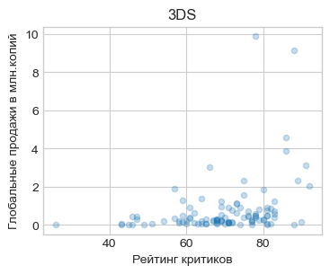

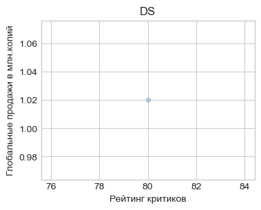

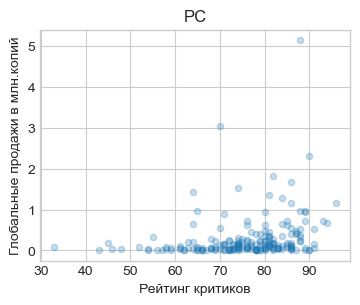

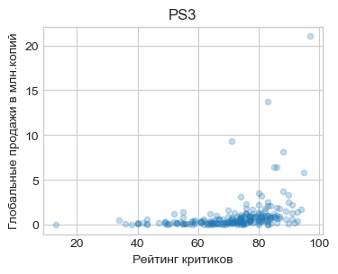

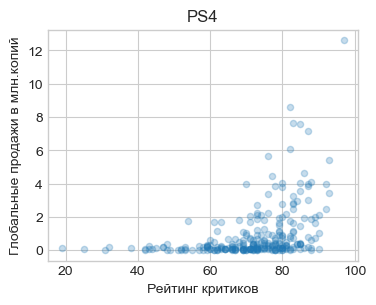

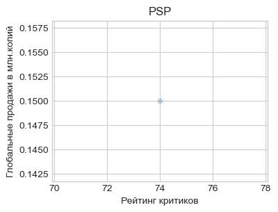

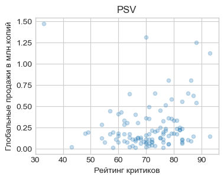

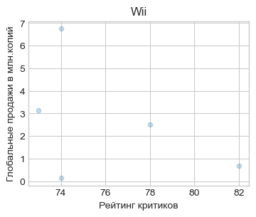

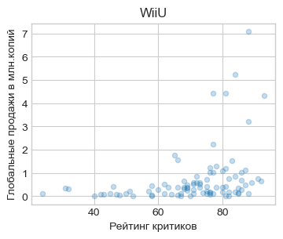

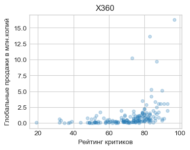

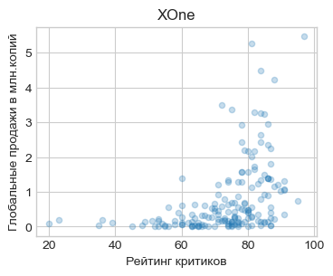

```python
# построим диаграммы рассеяния и рейтинга критиков для всех платформ в актуальных данных(2012-2016 гг.)
for name, group_data in games_set.groupby('platform'):
    group_data.plot(
        kind = 'scatter',
        figsize = (4,3),
        x = 'critic_score',
        y = 'total_sales',
        ylabel = 'Глобальные продажи в млн.копий',
        xlabel = 'Рейтинг критиков',
        title = name,
        alpha = 0.25)
    None
```

#### Вывод

- корреляции рейтинга пользователей и продаж в целом нет; в отдельных случаях связь показателей отрицательная: игры с низким пользовательским рейтингом могут продаваться лучше, чем игры с более высоким рейтингом; тоже самое можно сказать об играх с высокими пользовательскими оценками; это единичные случаи;
- корреляция продаж и рейтинга критиков слабо-положительная; есть отдельные игры с высоким рейтингом пользователей, которые продаются лучше других, однако это нельзя назвать общей тенденцией; в сегменте игр с высокой оценкой (выше медианного балла) влияние оценок критиков на объем продаж более выражено;
- что рейтинги пользователей и критиков - не основной фактор, влияющий на продажи компьютерных игр, а один из многих; роль положительных оценок критиков более значима для продаж, нежели роль оценок пользователей (вероятно, через обзоры и отзывы критиков пользователи чаще узнают о новых играх).

### Какие жанры компьютерных игр наиболее прибыльные

```python
# Сделаем сводную таблицу по продажам игр разных жанров
genre_set = games_set.pivot_table(index = 'genre', values = 'total_sales', aggfunc = {'sum','count', 'mean', 'median'})
genre_set.columns = ['number_of_games', 'sales_mean', 'sales_median', 'total_sales']
```

```python
genre_set.sort_values('number_of_games', ascending = False)
```

| genre | number_of_games | sales_mean | sales_median | total_sales |
| --- | --- | --- | --- | --- |
| Action | 1031 | 0.427856 | 0.120 | 441.12 |
| Role-Playing | 370 | 0.521081 | 0.140 | 192.80 |
| Adventure | 302 | 0.097450 | 0.030 | 29.43 |
| Sports | 268 | 0.675634 | 0.240 | 181.07 |
| Shooter | 235 | 1.296723 | 0.440 | 304.73 |
| Misc | 192 | 0.442917 | 0.120 | 85.04 |
| Racing | 115 | 0.465217 | 0.140 | 53.50 |
| Fighting | 109 | 0.408165 | 0.130 | 44.49 |
| Platform | 85 | 0.717647 | 0.210 | 61.00 |
| Simulation | 80 | 0.439000 | 0.120 | 35.12 |
| Strategy | 71 | 0.187887 | 0.080 | 13.34 |
| Puzzle | 28 | 0.174643 | 0.045 | 4.89 |

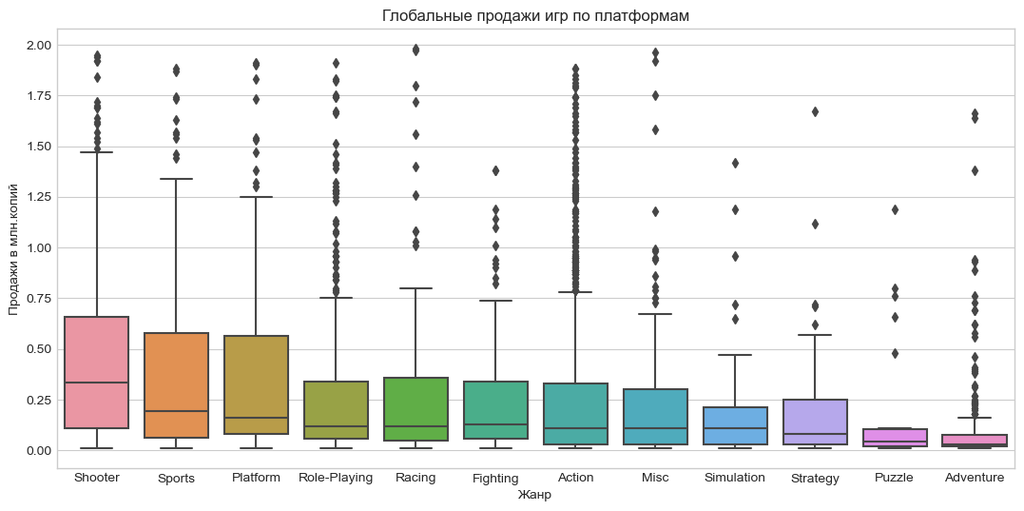

```python
#создаем переменную для сортировки
order_sales = (games_set.groupby('genre')['total_sales']
               .median().reset_index().sort_values('total_sales', ascending = False)
              )

#строим график
plt.figure(figsize=(13,6))

(
sns.boxplot(y='total_sales', x='genre',
            data=games_set.query('total_sales <= 2'),
            order = order_sales['genre'],
          )
            .set (title='Глобальные продажи игр по платформам', xlabel = 'Жанр', ylabel = 'Продажи в млн.копий')

)

plt.show()
```

По показателю медианных продаж жанр Action не попал даже в первую тройку: большинство экшн-игр продается на уровне ниже среднего, есть единичные очень успешные продукты. А вот в жанрах Shooter, Sports, Platform - половина игр стабильно хорошо продается.

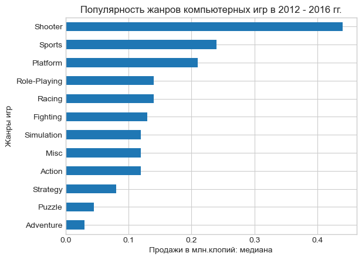

```python
#Выведем на график медианное значение продаж в разрезе по жанрам
genre_set.sort_values('sales_median').plot(
kind = 'barh',
y = 'sales_median',
grid = 'True',
title = 'Популярность жанров компьютерных игр в 2012 - 2016 гг.',
ylabel = 'Жанры игр',
xlabel = 'Продажи в млн.клопий: медиана',
legend = False)
None
```

#### Вывод:

Однако для жанра Экшн аномально-высокие продажи наблюдаются для отдельных игр, при этом половина игр продается тиражом почти в 4 раза меньшим, чем Шутеры и в два раза меньшим, чем Спорт - 0,12 млн копий.

Оценка популярность жанров на основании медианных значений продаж дает более четкую картину:

- наиболее высокие стабильные продажи у игр-шутеров(половина игр продается тиражом 0,44 млн.копий),
- на втором месте - спорт(0,24 млн копий медианные продажи),
- на третьем - жанр Platform (0,21 млн копий).

# Портрет пользователя компьютерных игр в Европе, Северной Америке и Японии

## Портрет пользователя в Европе

```python
print(
    'Рейтинг платформ компьютерных игр у Европейских пользователей(по медианному значению продаж в млн.копий)',
    (
        games_set.query('eu_sales > 0')
        .pivot_table(index = 'platform', values = 'eu_sales',  aggfunc = {'median'})
        .sort_values('median', ascending = False)
    )
)
```

```
Рейтинг платформ компьютерных игр у Европейских пользователей(по медианному значению продаж в млн.копий)           median
platform
PS4        0.160
PS3        0.130
X360       0.120
PSP        0.110
WiiU       0.100
Wii        0.090
XOne       0.090
3DS        0.080
PC         0.060
PSV        0.040
DS         0.035
```

```python
print(
    'Рейтинг жанров компьютерных игр у Европейских пользователей(по медианному значению продаж в млн.копий)',
    (
        games_set.query('eu_sales > 0')
        .pivot_table(index = 'genre', values = 'eu_sales',  aggfunc = {'median'})
        .sort_values('median', ascending = False)
    )
)
```

```
Рейтинг жанров компьютерных игр у Европейских пользователей(по медианному значению продаж в млн.копий)               median
genre
Shooter        0.210
Platform       0.120
Racing         0.115
Sports         0.110
Action         0.090
Misc           0.090
Fighting       0.080
Role-Playing   0.080
Simulation     0.080
Strategy       0.080
Adventure      0.040
Puzzle         0.020
```

## Портрет пользователя в Северной Америке

```python
print(
    'Рейтинг платформ компьютерных игр у Северо-Американских пользователей(по медианному значению продаж в млн.копий)',
    (
        games_set.query('na_sales > 0')
        .pivot_table(index = 'platform', values = 'na_sales',  aggfunc = {'median'})
        .sort_values('median', ascending = False)
    )
)
```

```
Рейтинг платформ компьютерных игр у Северо-Американских пользователей(по медианному значению продаж в млн.копий)           median
platform
Wii        0.330
X360       0.200
WiiU       0.170
DS         0.150
XOne       0.150
PS3        0.140
3DS        0.130
PS4        0.110
PC         0.090
PSP        0.065
PSV        0.050
```

```python
print(
    ' Рейтинг жанров компьютерных игр у Северо-Американских пользователей(по медианному значению продаж в млн.копий)',
    (
        games_set.query('na_sales > 0')
        .pivot_table(index = 'genre', values = 'na_sales',  aggfunc = {'median'})
        .sort_values('median', ascending = False)
    )
)
```

```
 Рейтинг жанров компьютерных игр у Северо-Американских пользователей(по медианному значению продаж в млн.копий)               median
genre
Shooter        0.225
Sports         0.210
Misc           0.130
Action         0.120
Platform       0.120
Role-Playing   0.110
Fighting       0.100
Simulation     0.100
Strategy       0.100
Puzzle         0.090
Racing         0.080
Adventure      0.050
```

## Портрет пользователя в Японии

```python
print(
    'Рейтинг платформ компьютерных игр в Японии(по медианному значению продаж в млн.копий)',
    (
        games_set.query('jp_sales > 0')
        .pivot_table(index = 'platform', values = 'jp_sales',  aggfunc = {'median'})
        .sort_values('median', ascending = False)
    )
)
```

```
Рейтинг платформ компьютерных игр в Японии(по медианному значению продаж в млн.копий)           median
platform
Wii        0.195
3DS        0.085
WiiU       0.080
DS         0.050
PS3        0.050
PS4        0.050
PSP        0.030
PSV        0.030
X360       0.020
XOne       0.010
```

```python
print(
    'Рейтинг жанров компьютерных игр в Японии(по медианному значению продаж в млн.копий)',
    (
        games_set.query('jp_sales > 0')
        .pivot_table(index = 'genre', values = 'jp_sales',  aggfunc = {'median'})
        .sort_values('median', ascending = False)
    )
)
```

```
Рейтинг жанров компьютерных игр в Японии(по медианному значению продаж в млн.копий)               median
genre
Puzzle         0.110
Role-Playing   0.080
Sports         0.070
Misc           0.060
Strategy       0.060
Platform       0.050
Simulation     0.050
Fighting       0.045
Action         0.040
Shooter        0.040
Racing         0.030
Adventure      0.020
```

Первое место по показателю медианных продаж во всех регионах-конкурентах занимают японские платформы:

- в Японии и Северной америке это WII (Японская компания Nintendo)
- Европе - PS4 и PS3(Sony PlayStation)

В японии американские производители не вошли в top-5 игровых платформ по продажам, основная часть японского рынка принадлежит национальному производителю.

Если говорить о жанрах, приоритеты пользователей Сереной Америки и Европы схожи: они предпочитают в первую очередь Шутеры. В топ-5 европейцев и северо-американцев также вошли (правда - с разными позициями) жанры Platform, Action, Sports.

Входят в топ-5 европейцев, и не попали в рейтинг североамриканцев Гонки.

Рейтинг жанров для Японии отличается: здесь больше всего любят жанры Puzzle и Role-Playing, на третьем месте Sports, на пятом - стратегии.

## Влияет ли рейтинг ESBR на продажи отдельно взятом регионе?

```python
games_set['rating'].value_counts()
```

```
rating
M       498
T       412
E       395
E10+    306
Name: count, dtype: int64
```

```python
#Посмотрим, как продаются игры отедльных категорий в целом
games_set.pivot_table(index = 'rating', values = 'total_sales', aggfunc = {'count', 'mean', 'median'}).sort_values('median', ascending = False)
```

| rating | count | mean | median |
| --- | --- | --- | --- |
| M | 498 | 1.024317 | 0.380 |
| E10+ | 306 | 0.508137 | 0.305 |
| E | 395 | 0.727013 | 0.230 |
| T | 412 | 0.395485 | 0.160 |

Игр в массиве принадлежат к одной из четырех категорий (E, T, M, E10+). Рассмотрим, как продаются игры каждой из категорий в трех регионах.

```python
#считаем количество игр с рейтингом, проданных в каждой стране, и средние продажи по ним
esbr_jp = (
    games_set.query('jp_sales > 0')
    .pivot_table(index = 'rating', values = 'jp_sales', aggfunc = {'count', 'mean', 'median'})
)
esbr_jp.columns = ['jp_num_games', 'jp_mean_sls', 'jp_median_sls']
```

```python
esbr_eu = (
    games_set.query('eu_sales > 0')
    .pivot_table(index = 'rating', values = 'eu_sales', aggfunc = {'count', 'mean', 'median'})
)
esbr_eu.columns = ['eu_num_games', 'eu_mean_sls', 'eu_median_sls']
```

```python
esbr_na = (
    games_set.query('na_sales > 0')
    .pivot_table(index = 'rating', values = 'na_sales', aggfunc = {'count', 'mean', 'median'})
)
esbr_na.columns = ['na_num_games', 'na_mean_sls', 'na_median_sls']
```

```python
esbr_games_sales = esbr_eu.join(esbr_na, how = 'left').join(esbr_jp, how = 'left')
esbr_games_sales.sort_values('eu_median_sls', ascending = False)
```

| rating | eu_num_games | eu_mean_sls | eu_median_sls | na_num_games | na_mean_sls | na_median_sls | jp_num_games | jp_mean_sls | jp_median_sls |
| --- | --- | --- | --- | --- | --- | --- | --- | --- | --- |
| M | 459 | 0.422571 | 0.150 | 454 | 0.510066 | 0.20 | 227 | 0.093392 | 0.05 |
| E10+ | 281 | 0.197046 | 0.120 | 266 | 0.284586 | 0.17 | 67 | 0.122239 | 0.04 |
| E | 336 | 0.336399 | 0.095 | 297 | 0.385084 | 0.14 | 105 | 0.269810 | 0.08 |
| T | 318 | 0.166541 | 0.065 | 306 | 0.215752 | 0.09 | 228 | 0.114123 | 0.06 |

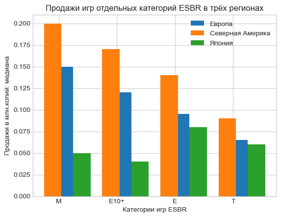

```python
# проиллюстрируем разницу в медианных продажах на графике

cat = ['M', 'E10+', 'E', 'T']
x = np.arange(len(cat))

g1 = list(esbr_games_sales.sort_values('eu_median_sls', ascending = False).loc[:, 'eu_median_sls'])
g2 = list(esbr_games_sales.sort_values('eu_median_sls', ascending = False).loc[:, 'na_median_sls'])
g3 = list(esbr_games_sales.sort_values('eu_median_sls', ascending = False).loc[:, 'jp_median_sls'])


width = 0.3

fig, ax = plt.subplots()

rects1 = ax.bar(x + width/3, g1, width, label='Европа')
rects2 = ax.bar(x - width/3, g2, width, label='Северная Америка')
rects3 = ax.bar(x + 4*width/3, g3, width, label='Япония')

ax.set_title('Продажи игр отдельных категорий ESBR в трёх регионах')
ax.set_xlabel('Категории игр ESBR')
ax.set_ylabel('Продажи в млн.копий: медиана')
ax.set_xticks(x)
ax.set_xticklabels(cat)
ax.legend()
plt.show()
```

Мы видим, что продажи игр отдельных категорий в Японии отличаются от продаж в Северной Америке и США

- В Японии продается почти в два раза меньше игр с рейтингом ESBR, чем в США и Европе (что отчасти объясняетя меньшими объемами рынка игр в Японии).
- Если смотерть на суммарные глобальные продажи игр в млн.копий(берем медианное значение продаж в качестве показателя для сравнения), то:
  - на первом месте по продажам игры категории M(для взрослых старше 17 лет)
  - на втором Е10+(для детей старше 10 лет)
  - на третьем E(для всех)
  - на последнем Т(для подростков старше 13 лет)
- В Европе и Северной Америке предпочтения пользователей одинаковы и повторяют глобальный рейтинг.
- В Японии выбор покупателей отличается: наибольший объем продаж - это игры для всех (категория Е), на втором - игры для подростков(Т), на третьем взрослые игры(М) и на последнем месте - игры Е10+.

## Портрет пользователя компьютерных игр в разрезе по регионам

*1. Общая характеристика рынка компьютерных игр в трех регионах:*

Рынок компьютерных игр по-разному рзвивался в Северной Америке, Европе и США:

- По объемам продаж компьютерных игр лидирует США, на втором месте - Европа, на третьем Япония. До 1997 г. Япония по продажам опережала Европу, а между 1990 и 1995 гг. опережала даже и США. После 1997 г. в Японии наблюдается сокращение рынка.
  - После 2008 г. наблюдается сокращение рынка компьютерных игр во всех странах. В США падение особенно резкое: североамериканский рынок, который до 2008 г. превосходил Европейский в 2 или более раз, к 2014 г.сравнялся с ним.
  - Для всех трех стран характерна общая тенеднеция - сокращение продаж после 2012 г.
  - Разница в объемах продаж по регионам объясняет разницу в долях продаж по отдельным платформам и жанрам игр (если в США в целом до недавнего времени продавалось в разы больше игр чем в Японии или Европе, то и по отдельным категориям игр продаж буде больше).

*2. Популярность отдельных игровых платформ по регионам:*

На рынке платформ компьютерных игр за первенство конкурируют компании США и Японии, и эта конкуренция наблюдается во всех регионах.

Первое место по показателю медианных продаж во всех регионах-конкурентах занимают японские платформы:

- в Японии и Северной америке это WII (Японская компания Nintendo)
- Европе - PS4 и PS3(Sony PlayStation)

В японии американские производители не вошли в top-5 игровых платформ по продажам, основная часть японского рынка принадлежит национальному производителю.

*Топ-5 игровых платформ в зависимости от региона (по показателю медианных продаж в млн.копий):*

**Европа:**

- PS4 0.16/Sony PlayStation/
- PS3 0.13/Sony PlayStation/
- X360 0.12/Microsoft/
- PSP 0.11/Sony PlayStation/
- WiiU 0.10 /Nintendo/

**Северная Америка:**

- Wii 0.33 /Nintendo/
- X360 0.20 /Microsoft/
- WiiU 0.17 /Nintendo/
- DS 0.15 /Nintendo/
- XOne 0.15 /Microsoft/

**Япония:**

- Wii 0.195 /Nintendo/
- 3DS 0.085 /Nintendo/
- WiiU 0.080 /Nintendo/
- DS 0.050 /Nintendo/
- PS3,PS4 0.050 Sony PlayStation/

*3. Как продаются игры разных жанров в зависимости от региона?*

Приоритеты пользователей Сереной Америки и Европы схожи: они предпочитают в первую очередь Шутеры. В топ-5 европейцев и северо-американцев также вошли (правда - с разными позициями) жанры Platform, Action, Sports. Входят в топ-5 европейцев, и не попали в верхушку рейтинга североамриканцев Гонки. Рейтинг жанров для Японии отличается: здесь больше всего любят жанры Puzzle и Role-Playing, на третьем месте Sports, на пятом - стратегии.

*Топ-5 жанров компьютерных игр в зависимости от региона (по показателю медианных продаж в млн.копий):*

**Европа:**

- Shooter 0.210
- Platform 0.120
- Racing 0.115
- Sports 0.110
- Action 0.090

**Северная Америка:**

- Shooter 0.225
- Sports 0.210
- Misc 0.130
- Action 0.120
- Platform 0.120

**Япония:**

- Puzzle 0.11
- Role-Playing 0.08
- Sports 0.07
- Misc 0.06
- Strategy 0.06

*4. Продажи игр в зависимости от рейтинга ESBR hразличаются в зависимости от региона:*

- В Японии продается почти в два раза меньше игр с рейтингом ESBR, чем в США и Европе (что отчасти объясняетя меньшими объемами рынка игр в Японии).
- В Европе и Северной Америке предпочтения пользователей одинаковы и повторяют глобальный рейтинг.
- В Японии выбор покупателей отличается: наибольший объем продаж - это игры для всех (категория Е), на втором - игры для подростков(Т), на третьем взрослые игры(М) и на последнем месте - игры Е10+.

# Сравнение пользовательских рейтингов для игр разных платформ и жанров (проверка гипотез)

```python
#для проверки гипотез о равенстве средних пользовательских рейтингов удалим отсутствующие данныев столбце user_score
df_games_h = games_set.dropna(subset = ['user_score'])
df_games_h['user_score'].isna().sum()
```

```
0
```

## Средние пользовательские рейтинги платформ Xbox One и PS3 одинаковые

```python
for platform in ['PS3', "XOne"]:
    print (platform, 'средний пользовательский рейтинг:',
           df_games_h.query('platform == @platform')['user_score'].mean())
```

```
PS3 средний пользовательский рейтинг: 6.532862190812721
XOne средний пользовательский рейтинг: 6.521428571428572
```

Наблюдаемые средние рейтинги платформ XOne и PS3 различаются незначительно, это 6.5 баллов. Проверим гипотезу о равенстве рейтингов этих двух платформ.

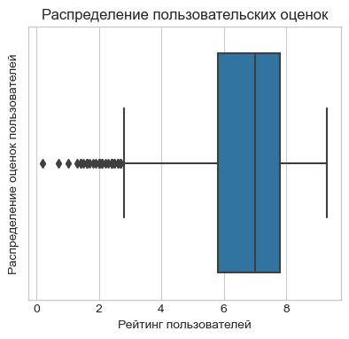

```python
plt.figure(figsize=(10, 4))


ax = plt.subplot(1,2,1)
ax = sns.boxplot(x="user_score", data=df_games_h)
ax.set_title('Распределение пользовательских оценок')
ax.set_xlabel('Рейтинг пользователей')
ax.set_ylabel('Распределение оценок пользователей')

plt.show()
```

В переменной рейтинг пользователей есть выбросы. Для проверки гипотезы о равенстве средних рейтингов используем непараметрический тест Манна - Уитни.

```python
rating_xone = df_games_h.loc[df_games_h['platform'] == 'XOne', 'user_score']
rating_ps3 = df_games_h.loc[df_games_h['platform'] == 'PS3', 'user_score']


alpha = 0.05

results = st.mannwhitneyu(rating_xone, rating_ps3)

print('p-значение: ', results.pvalue)

if results.pvalue < alpha:
    print('Отвергаем нулевую гипотезу, рейтинги платформ различаются')
else:
    print('Не отвергаем нулевую гипотезу, нет значимой разницы пользовательских рейтингов платформ PS3 и X0ne')
```

```
p-значение:  0.2802696286139972
Не отвергаем нулевую гипотезу, нет значимой разницы пользовательских рейтингов платформ PS3 и X0ne
```

```python
for genre in ['Action', "Shooter"]:
    print (genre, 'средний пользовательский рейтинг:',
           df_games_h.query('genre == @genre')['user_score'].mean())
```

```
Action средний пользовательский рейтинг: 6.825047801147227
Shooter средний пользовательский рейтинг: 6.435897435897436
```

Средний рейтинг игр в жанре экшн выше, чем в жанре шутер. Сделаем статистический тест для проверки значимости различий рейтингов игр двух жанров. Так как в переменной user_score есть выбросы, выбираем непараметрический тест Манна-Уитни.

##### Сформулируем гипотезу

H0: Средние пользовательские рейтинги игр жанров Action и Shooter одинаковые

H1: Средние пользовательские рейтинги игр жанров Action и Sooter различаются

```python
rating_action = df_games_h.loc[df_games_h['genre'] == 'Action', 'user_score']
rating_shooter = df_games_h.loc[df_games_h['genre'] == 'Shooter', 'user_score']

alpha = 0.05

results = st.mannwhitneyu(rating_action, rating_shooter)

print('p-значение: ', results.pvalue)

if results.pvalue < alpha:
    print('Отвергаем нулевую гипотезу, средние рейтинги жанров Экшн и Шутер различаются')
else:
    print('Не отвергаем нулевую гипотезу, нет значимой разницы пользовательских рейтингов двух жанров')
```

```
p-значение:  0.00032780102086096304
Отвергаем нулевую гипотезу, средние рейтинги жанров Экшн и Шутер различаются
```

# Общий вывод

## Общая характеристика рынка компьютерных игр

Рынок компьютерных игр до 2016 г. развивался следующим образом:

- В 90-е гг. 20 в. И в первое десятилетие 21 в. наблюдался значительный рост продаж, прежде всего – в Северной Америке и Европе. После 2008 г. наблюдается снижение продаж компьютерных игр во всех странах.
- К 2014 г. объем продаж в Северной Америке (которая лидировала в предыдущих 20 лет) приблизился к показателям Европе и Японии.
- Всего за период с 1980 по 2016г. было выпущено 11426 уникальных игр
- Основное количество игр было выпущено за 2001 - 2016 гг., когда ежегодно выпускалось 400+ игр.; наиболее плодотворным был период с 2006 по 2011 гг.(более 700 игр выпускалось ежегодно). В период с 1994 по 2000 игр выпускалось уже меньше - от 100 до 350 в год.
- В период с 2012 по 2016 гг. объем игр снизился по сравнению с предыдущим периодом, но оставался достаточно стабильным в течение 5 лет.

## Популярность отдельных платформ

Цикл жизни большинства платформ - это примерно 10 лет: первые 2-3 года платформа набирает популярность, потом 4-5 лет можно наблюдать активные продажи, и далее постепенно популярность падает, на смену приходя новые платформы.

Наиболее продаваемой за все годы была платформа PS2: за 12 лет для нее было продано 1233,56 млн копий видеоигр.

Наиболее популярные (по количеству проданных для них копий игр) платформы и успешные годы их продаж следующие:

- PS2(1233,56 млн копий) с 2000 по 2011 гг, наиболее успешные - 2002 - 2005 гг.
- Х360 (961,24 млн копий) с 2005 по 2016 гг, наиболее успешные - 2007 - 2012 гг.
- PS3 (931,34 млн.копий) с 2006 по 2016 гг, наиболее успешные - 2008 - 2013 гг.
- WII (891,18 млн.копий) с 2006 по 2016 гг, наиболее успешные - 2006 - 2010 гг.
- DS (802,78 млн.копий) с 2004 по 2013 гг, наиболее успешные - 2005 - 2010 гг.
- PS (727,78 млн.копий) с 1994 по 2003 гг, наиболее успешные - 1996 - 2000 гг.

## Актуальный период: факторы успешных продаж компьютерных игр

### Какой период считать актуальным для понимания прогноза на 2017 г.?

Для понимания следующего года (2017) важен период **с 2012 по 2016 гг.**, который отличается следующим:

- объемы выпускаемых игр и количество продаваемых копий снизились по сравнению с предыдущим периодом, но оставались достаточно стабильными в течение 5 лет;
- к 2012 г. перестали продаваться игры на платформе PS2, которая до 2012 г. была самой популярной (за всю историю видеоигр больше всего копий было продано именно для PS2); факторы успеха PS2 не должны напрямую влиять на продажи после 2012 г., так как платформа ушла с рынка;

### Популярные платформы в актуальном периоде

Пятерка лидеров по показателю объемов глобальных продаж в актуальном периоде:

- PS3 (314.14 млн.копий)
- PS4 (288.79 млн.копий)
- X360 (236.54 млн.копий)
- 3DS (194.61 млн.копий)
- XOne (159.32 млн.копий)

У трех из пяти наиболее популярных платформ продажи в период с 2012 по 2016 гг. планомерно снижались, вряд ли в 2016 г будет рост. Речь идет о – 3DS, PS3, X360 .

Продажи XOne и PS4 начали расти с 2013 г. Вероятно, за 2016 г. данные неполные, и продажи этих платформ либо продолжают расти, либо стабильны. Таким образом, **XOne и PS4 можно считать перспективными и потенциально прибыльными**.

### Региональные особенности популярности платформ:

На рынке платформ компьютерных игр в Северной Америке и Европе за первенство конкурируют компании США и Японии. В Японии американские производители не вошли в top-5 игровых платформ по продажам, основная часть японского рынка принадлежит национальному производителю.

Первое место по показателю медианных продаж во всех регионахзанимают японские платформы:

- в Японии и Северной америке это WII (Японская компания Nintendo)
- Европе - PS4 и PS3(Sony PlayStation)

### Влияние рейтинга пользователей и критиков на продажи игр:

- Рейтинг пользователей не влияет на успехи продаж, в отдельных случаях игры с низким пользовательским рейтингом могут продаваться лучше, чем игры с более высоким рейтингом и наоборот;
- Влияние рейтинга критиков на продажи игр выражено слабо (корреляция слабо-положительная);
- В сегменте игр с высокой оценкой (выше медианного балла) влияние оценок критиков на объем продаж более выражено;
- Роль оценок критиков более значима для продаж, нежели роль оценок пользователей: вероятно, через обзоры и отзывы критиков пользователи чаще узнают о новых играх.

### Популярность жанров компьютерных игр:

- Наиболее высокие стабильные продажи у игр-шутеров(половина игр продается тиражом 0,44 млн.копий), на втором месте Спорт(0,24 млн копий медианные продажи), на третьем - жанр Platform (0,21 млн копий).
- Экшн-игры хотя и лидируют по объемам продаж, по медианному значению продаж находятся в "хвосте" рейтинга (половина игр продается тиражом почти в 4 раза меньшим, чем Шутеры и в два раза меньшим, чем Спорт - 0,12 млн копий).
  - При этом, средний пользовательский рейтинг игр жанра Action выше рейтинга игр жанра Shooter, разница статистически значима.
  - Наиболее низкие продажи (в глобальном рейтинге) - у паззлов, стратегий, приключенческих игр.

Важно учитывать региональную специфику предпочтений пользователей.

- Приоритеты пользователей Сереной Америки и Европы схожи и сопоставимы с глобальным рейтингом жанров: они предпочитают в первую очередь Шутеры. В топ-5 европейцев и северо-американцев также вошли, с разными позициями, жанры Platform, Action, Sports.
- Входят в топ-5 европейцев, НО не попали в рейтинг североамриканцев Гонки.
- Рейтинг жанров для Японии отличается: здесь больше всего любят жанры Puzzle и Role-Playing, на третьем месте Sports, на пятом - стратегии. Таким образом, жанры с низкими продажами в глобальном рейтинге занимаю существенную долю рынка в Японии.

### Влияние рейтинг ESBR на объем продаж игр по-разному проявляется на уровне регионов:

- В Японии продается почти в два раза меньше игр с рейтингом ESBR, чем в США и Европе.
  - На первом месте по медианным продажам игры категории M(для взрослых старше 17 лет), на втором Е10+(для детей старше 10 лет), на третьем E(для всех), на последнем Т(для подростков старше 13 лет)
- В Европе и Северной Америке продажи повторяют глобальный рейтинг.
- В Японии выбор покупателей отличается: наибольший объем продаж - это игры для всех (категория Е), на втором - игры для подростков(Т), на третьем взрослые игры(М) и на последнем месте - игры Е10+.

## Общие рекомендации для продавца компьютерных игр в 2017 г.

- Высока вероятность, что платформы XOne и PS4 (продажи которых начали расти с 2013) окажутся перспективными и покажут рост.
- Наиболее популярными у пользователей во всем мире являются игры жанров Shooter, Sports, Platform; вместе с тем, популярность жанров зависит от культурных особенностей региона (что наблюдается на примере японских пользователей), и потому важно проанализировать предпочтения пользователей своего региона.
- Продажи игр разных категорий (по рейтингу ESBR) также различаются для США, Европы и Японии; при выборе категорий игр надо учитывать региональную специфику.
- Рейтинг пользователей незначительно и в ряде случаев неоднозначно влияет на продажи; влияние рейтинга критиков выражено слабо, но его, тем не менее, важно учитывать как один из факторов успешных продаж.